# TMB and the Saddlepoint Approximation

Berent Lunde

2019-04-06

We seek to employ the framework of the R package Template Model Builder [**TMB**](https://github.com/kaskr/adcomp) (Kristensen et al. 2016) which approximately “integrates out” latent variables using the Laplace approximation – to automatically solve the inner problem of the saddlepoint approximation (SPA) and return the negative logarithm of the SPA. The table of contents gives an idea of how the document is laid out. And all code can be found [in this Github repository](https://github.com/Blunde1/spaTMB).

### Introduction to the Laplace approximation

We consider the Laplace approximation in the context of likelihood estimation, following (read: stolen from) (Kristensen et al. 2016) completely: Let $f(\mathbf{u},\theta)$ denote the negative joint log-likelihood of the data and the random effects. This depends on the unknown random effects $\mathbf{u}\in\mathbb{R}^n$ and parameters $\theta\in\mathbb{R}^m$. The maximum likelihood estimate for θ maximizes
$$\begin{align*}
L(\theta) = \int_{\mathbb{R}^n} \exp(-f(\mathbf{u},\theta)) d\mathbf{u},
\end{align*}$$
i.e., the random effects $\mathbf{u}$ have been integrated out. High-dimensional integration is, in general, difficult, but can be achieved by applying the Laplace approximation, giving the approximation
$$\begin{align*}
L^*(\theta) = \frac{\sqrt{2\pi}^n \exp(-f(\mathbf{{\hat{\mathbf{u}}(\theta)}},\theta))}{\sqrt{\| \nabla_\mathbf{u}^2f({\hat{\mathbf{u}}(\theta)},\theta) \|}},
\end{align*}$$
where

- ${\hat{\mathbf{u}}(\theta)}= \arg\min_\mathbf{u} f(\mathbf{u},\theta)$,
- and $\nabla_\mathbf{u}^2f(\mathbf{u},\theta)$ is the Hessian matrix, denoted $H(\theta)$ from here on out.

### Introduction to the Saddlepoint approximation

The SPA takes as a vantage point the following inversion integral:
$$\begin{align*}
f_\mathbf{Y}(\mathbf{y};\theta) = \frac{1}{(2\pi)^n} \int_{\mathbb{R}^n} e^{( (\tau + i \mathbf{s})^T \mathbf{y} ) }
M_\mathbf{Y}(\tau + i\mathbf{s} ; \theta) d\mathbf{s}.
\end{align*}$$
where $i=\sqrt{-1}$, $M_\mathbf{Y}(\mathbf{s}) = E(\exp(\mathbf{s}^T\mathbf{y}))$ is the moment generating function (MGF), $\tau\in\mathbb{R}^n$ such that $E(\exp(\tau^T\mathbf{y})) < \infty$ (Butler 2007).

Applying the Laplace approximation to this integral, we obtain multivaraite saddlepoint approximation:
$$\texttt{spa}(f;\mathbf{y}) =
\frac{\exp\left(K_\mathbf{y}({\hat{\mathbf{s}}(\theta)};\theta)-{\hat{\mathbf{s}}(\theta)}^T \mathbf{y}\right)}
{(2\pi)^{(n/2)}\sqrt{\| \nabla_\mathbf{s}^2 K_\mathbf{y}({\hat{\mathbf{s}}(\theta)};\theta) \|}}$$

where

- $K_\mathbf{y}(\mathbf{s};\theta) = \log M_\mathbf{y}(\mathbf{s};\theta)$,
- $\nabla_\mathbf{s}^2 K_\mathbf{y}(\mathbf{s};\theta)$ is the Hessian matrix,
- and the saddlepoint ${\hat{\mathbf{s}}(\theta)}$ solves ${\hat{\mathbf{s}}(\theta)}= \arg\min_{\mathbf{s}} K_\mathbf{y}(\mathbf{s};\theta) - \mathbf{s}^T\mathbf{y}$

see (Kleppe and Skaug 2008) for a very general derivation, or the standard reference (Butler 2007).

### Introduction to **TMB**

Template model builder, or **TMB** for short, wraps (on the C++ side) the high-performance C++ libraries **Eigen** (a C++ template library for linear algebra: matrices, vectors, numerical solvers, and related algorithms) and **CppAD** (templated automatic differentiation using operator overloading), for R users to obtain highly efficient evaluations of objective functions and their derivatives (gradient and Hessian) and with automatically performing the Laplace approximation as its high-point.

The **TMB** user only has to specify the objective function $f(\theta)$, or $f(\mathbf{u}, \theta)$ in the case of latent variables $\mathbf{u}$ that needs to be integrated out, and **TMB** takes care of the rest. Specifically, the (negative log) Laplace approximation to the negative joint log-likelihood is returned:
$$- \log L^*(\theta) = -n \log \sqrt{2\pi} + \frac{1}{2}\log \| H(\theta) \| + f({\hat{\mathbf{u}}(\theta)},\theta).$$
Using this, the likelihood estimates of $\theta$, i.e. $\hat{\theta}=\arg\min_\theta - \log L^*(\theta)$, can be found very efficiently, because **TMB** also returnes the gradient and (finite difference approximation) Hessian of $-\log L^*(\theta)$ w.r.t. $\theta$.

#### Example from TMB

**R code**

```r
## Simulate data
set.seed(123)
n <- 10000
sigma <- .3
phi <- .8
simdata <- function(){
    u <- numeric(n)
    u[1] = rnorm(1)
    if(n>=2)
        for(i in 2:n){
            u[i] = phi * u[i-1] + rnorm(1, sd = sqrt(1 - phi^2))
        }
    u <- u * sigma
    x <- as.numeric( rbinom(n, 1, plogis(u)) )
    data <- list(obs=x)
    data
}
data <- simdata()
parameters <- list(phi=phi, logSigma=log(sigma))

## Adapt parameter list
parameters$u <- rep(0,n)

require(TMB)
compile('laplace.cpp')
dyn.load(dynlib('laplace'))

obj <- MakeADFun(data, parameters, random="u", DLL="laplace")
obj$fn()

system.time( opt <- nlminb(obj$par,obj$fn,obj$gr) )
(sdr <- sdreport(obj))
```

**C++ code**

```c
#include <TMB.hpp>

template<class Type>
Type objective_function<Type>::operator() ()
{
  DATA_VECTOR(obs);
  PARAMETER(phi);
  PARAMETER(logSigma);
  PARAMETER_VECTOR(u);
  using namespace density;
  Type sigma= exp(logSigma);
  Type f = 0;
  f += SCALE(AR1(phi), sigma)(u);
  vector<Type> p = invlogit(u);
  f -= dbinom(obs, Type(1), p, true).sum();
  return f;
}
```

### Using **TMB** in numerical SPA calculations and parameter optimization

Set the goal of making **TMB** automatically solve the inner problem of the SPA, and returning the negative log SPA for the purpose of likelihood optimisation. Ideally, we would have **TMB** return
$$-\log \texttt{spa}(f,\mathbf{y})
= \frac{1}{2}\left( \log \| \nabla_\mathbf{s}^2 K_\mathbf{y}({\hat{\mathbf{s}}(\theta)};\theta) \| + n\log(2\pi) \right) -
\left(K_\mathbf{y}({\hat{\mathbf{s}}(\theta)};\theta)-{\hat{\mathbf{s}}(\theta)}^T \mathbf{y}\right).$$
However, to solve the inner problem of the SPA, we need to supply the following objective:
$$\begin{align*}
f(\mathbf{u},\theta) &= K_\mathbf{y}(\mathbf{s};\theta) - \mathbf{s}^T\mathbf{y} - n\log (2\pi)\\
&\sim K_\mathbf{y}(\mathbf{s};\theta) - \mathbf{s}^T\mathbf{y},
\end{align*}$$
where $\mathbf{s}$ is set to `random` (and hence, will be integrated out by **TMB**). However, **TMB** would then return
$$- \log L^*(\theta) = -\log \texttt{spa}(f,\mathbf{y}) + 2 \left(K_\mathbf{y}({\hat{\mathbf{s}}(\theta)};\theta)-{\hat{\mathbf{s}}(\theta)}^T \mathbf{y}\right).$$
i.e., the sign is reversed on $f(\mathbf{u},\theta) \sim K_\mathbf{y}({\hat{\mathbf{s}}(\theta)};\theta)-{\hat{\mathbf{s}}(\theta)}^T \mathbf{y}$. This is because, for the SPA, the Laplace approximation is calculated w.r.t. the objective
$$f(\mathbf{u},\theta) = K_\mathbf{y}(\mathbf{\tau} + i\mathbf{s};\theta) - (\mathbf{\tau} + i\mathbf{s})^T\mathbf{y} - n\log (2\pi),$$
where the imaginary unit, $i$, reverses the sign of the Hessian (w.r.t $\mathbf{\tau}$), replacing minimization with maximization in the the inner optimization and vice versa. **TMB** does not directly allow complex AD data types (while still possible inside TMB, see e.g. [this file on Github](https://github.com/Blunde1/it-ift/blob/master/implementation/includes/complex.hpp) and example use (advanced SPA calculations) in corresponding repository).

There are at least four possible solutions:

- Use the `autodiff` namespace to construct structs of $K$ and the inner problem, and a Newton type algorithm to solve it. This is not ideal, because all Newton iterations will be taped by **TMB**, while only the last two should be sufficient for derivatives w.r.t. $\theta$. See [this code for an example](https://github.com/Blunde1/HyperSDE/blob/master/HyperSDE/src/HyperSDE.cpp).
- Use `ADREPORT` on the quantities needed to build the negative $\log \texttt{spa}$ and its gradient
- Use the quantities in `obj$env` to build new `obj$fn` and `obj$gr`.
- Update `MakeADFun`with a `spa=TRUE` option, such that SPA calculations are performed instead of Laplace. This would essentially do the same as point three (but be under the hood).

I have done a hybrid between point 3 and 4; ideally I would like to make a branch on my TMB installation to do point 4, but I am on a Windows machine and hence not blessed with the developer version. If this works, I will still make a pull-request (however, untried) on MakeADFun with a SPA option to adcomp/TMB.

To update `MakeADFun` or the `obj$env`, the [source code](https://github.com/kaskr/adcomp/blob/master/TMB/R/TMB.R) must be studied. The following table summarizes my findings (conditioned on no special options evoked in the `MakeADFun` call). Here, we write $l$ for the Laplace approximation and $h$ for the functional form (but unsolved inner problem), denote partial derivatives by subscripts, i.e. $H=f_{\mathbf{u}\mathbf{u}}$, and write $\mathbf{\nu}=(\mathbf{u},\theta)$ for the collection of parameters.

[output not shown]

**A side note**

The expression $\nabla_\nu \log\|f_{\mathbf{u}\mathbf{u}}(u,\theta) \|$ in $`h(order==1)` is difficult and deserve special attention. From (Searle, Casella, and McCulloch 2009) page 457 or (Kristensen et al. 2016) eq.8, we have for an individual element $\nu_j$

$$\frac{\partial}{\partial \nu_j} \log\|f_{\mathbf{u}\mathbf{u}}(u,\theta) \| = \mathrm{tr}\left( f_{\mathbf{u}\mathbf{u}}(u,\theta)^{-1} \frac{\partial}{\partial \nu_j} f_{\mathbf{u}\mathbf{u}}(u,\theta) \right).$$
This can also be solved purely by using AD, see Table 1 in (Skaug and Fournier 2006).

From this summary, it should be clear that if we

1. Supply the objective function
   $$f(\mathbf{u},\theta) = K_\mathbf{y}(\mathbf{s};\theta) - \mathbf{s}^T\mathbf{y} - n\log (2\pi)$$
   With $\mathbf{s}$ set to `random`.
2. Manipulate `h(order=0)` to return the negative log SPA
   $$h(\mathbf{u},\theta)= -f(\mathbf{u},\theta) + \frac{1}{2}\log\| f_{\mathbf{u}\mathbf{u}}(\mathbf{u},\theta) \| - \frac{n}{2}\log(2\pi)$$
   .
3. Manipulate `h(order=1)` to the negative log spa derivative:
   $$\begin{align}
   h_\nu(\mathbf{u},\theta)= - f_\mathbf{\nu}(\mathbf{u},\theta) +
   \frac{1}{2}\nabla_\nu \log\|f_{\mathbf{u}\mathbf{u}}(u,\theta) \|
   \end{align}$$

then **TMB** will take care of the rest. The R code for the “fix” is provided below.

**R code for solution**

```r
# after MakeADFun
library(Matrix)
attach(obj$env)
# update h
obj$env$h <- function(theta=par, order=0, hessian, L, ...) {
    if(order == 0) {
        ##logdetH <- determinant(hessian)$mod
        logdetH <- 2*determinant(L)$mod
        ans <- -f(theta,order=0) + .5*logdetH - length(random)/2*log(2*pi) #### updated
        if(LaplaceNonZeroGradient){
            grad <- f(theta,order=1)[random]
            ans - .5* sum(grad * as.numeric( solveCholesky(L, grad) ))
        } else
            ans
    }
    else if(order == 1) {
        if(LaplaceNonZeroGradient)stop("Not correct for LaplaceNonZeroGradient=TRUE")
        ##browser()
        e <- environment(spHess)
        solveSubset <- function(L).Call("tmb_invQ",L,PACKAGE="TMB")
        solveSubset2 <- function(L).Call("tmb_invQ_tril_halfdiag",L,PACKAGE="TMB")
        ## FIXME: The following two lines are not efficient:
        ## 1. ihessian <- tril(solveSubset(L))
        ## 2. diag(ihessian) <- .5*diag(ihessian)
        ## Make option to solveSubset to return lower triangular part
        ## with diagonal halved. As it is now the output of solveSubset is
        ## symm _with upper storage_ (!) (side effect of cholmod_ptranspose)
        ## therefore tril takes long time. Further, "diag<-" is too slow.
        ## FIXED! :
        ihessian <- solveSubset2(L)
        ## Profile case correction (1st order case only)
        if(!is.null(profile)){
            ## Naive way:
            ##   ihessian[profile,] <- 0
            ##   ihessian[,profile] <- 0
            ## However, this would modify sparseness pattern and also not
            ## account for 'ihessian' being permuted:
            perm <- L@perm+1L
            ihessian <- .Call("tmb_sparse_izamd", ihessian, profile[perm], 0.0, PACKAGE="TMB")
        }

        ## General function to lookup entries A subset B.
        ## lookup.old <- function(A,B){
        ##   A <- as(tril(A),"dtTMatrix")
        ##   B <- as(tril(B),"dtTMatrix")
        ##   match(paste(A@i,A@j),paste(B@i,B@j))
        ## }
        ## General function to lookup entries A in B[r,r] assuming pattern of A
        ## is subset of pattern of B[r,r].
        lookup <- function(A,B,r=NULL){
            A <- tril(A); B <- tril(B)
            B@x[] <- seq.int(length.out=length(B@x)) ## Pointers to full B matrix (Can have up to 2^31-1 non-zeros)
            if(!is.null(r)){
                ## Goal is to get:
                ##     B <- forceSymmetric(B)
                ##     B <- B[r,r,drop=FALSE]
                ## However the internal Matrix code for
                ## "B[r,r,drop=FALSE]" creates temporary "dgCMatrix"
                ## thereby almost doubling the number of non-zeros. Need
                ## solution that works with max (2^31-1) non-zeros:
                B <- .Call("tmb_half_diag", B, PACKAGE="TMB")
                B <- tril( B[r,r,drop=FALSE] ) + tril( t(B)[r,r,drop=FALSE] )
            }
            m <- .Call("match_pattern", A, B, PACKAGE="TMB") ## Same length as A@x with pointers to B@x
            B@x[m]
        }
        if(is.null(e$ind1)){
            ## hessian: Hessian of random effect part only.
            ## ihessian: Inverse subset of hessian (same dim but larger pattern!).
            ## Hfull: Pattern of full hessian including fixed effects.
            if (!silent) cat("Matching hessian patterns... ")
            iperm <- invPerm(L@perm+1L)
            e$ind1 <- lookup(hessian,ihessian,iperm) ## Same dimensions
            e$ind2 <- lookup(hessian,e$Hfull,random)  ## Note: dim(Hfull)>dim(hessian) !
            if (!silent) cat("Done\n")
        }
        w <- rep(0,length=length(e$Hfull@x))
        w[e$ind2] <- ihessian@x[e$ind1]
        ## Reverse mode evaluate ptr in rangedirection w
        ## now gives .5*tr(Hdot*Hinv) !!
        ## return
        as.vector( -f(theta,order=1) ) +
            .Call("EvalADFunObject", e$ADHess$ptr, theta,
                  control=list(
                      order=as.integer(1),
                      hessiancols=as.integer(0),
                      hessianrows=as.integer(0),
                      sparsitypattern=as.integer(0),
                      rangecomponent=as.integer(1),
                      rangeweight=as.double(w),
                      dumpstack=as.integer(0),
                      doforward=as.integer(1)
                  ),
                  PACKAGE=DLL)
    }## order == 1
    else stop(sprintf("'order'=%d not yet implemented", order))
} ## end{ h }
```

### **spaTMB** example

Finally, an example for which we know the true solution is supplied: The Gaussian case.

First, we need to specify the objective function. That is, of course, the inner problem with a normalizing constant:

```c
#include <TMB.hpp>

template<class Type>
Type objective_function<Type>::operator() ()
{
    DATA_VECTOR(y);
    PARAMETER(mu);
    PARAMETER(logSigma);
    PARAMETER_VECTOR(s); // saddlepoints

    // Return K_y(s)-s^T y - n/2 log(2*pi)
    // K_y(s) = sum K_{y[i]}(s[i])
    // K_N(mu, logSigma)(s) = mu*s + sigma^2 * s^2 / 2

    Type sigma = exp(logSigma);
    int n = y.size();

    // Build CGF
    Type K = 0;
    for(int i=0; i<n; i++){
        K += mu * s(i) + 0.5*s(i)*s(i)*sigma*sigma;
    }

    // Build inner problem with normalization constant
    Type res = K - (s*y).sum() - n * log(2*M_PI);

    // report sigma
    ADREPORT(sigma);

    return res;
}
```

On the R side, we do what is described in the previous section:

```r
# Simulate data
set.seed(123)
n <- 10000
mu <- 3
sigma <- 1.5
y <- rnorm(n, mu, sigma)

# data and parameters
data <- list(y=y)
parameters <- list(mu=0, logSigma = log(1), s=numeric(n))

# Compile c++ code and load into R
library(TMB)
compile("gauss_spa_example.cpp")
```

[1] 0

```r
dyn.load(dynlib("gauss_spa_example"))

# create adfun, set s="random" for SPA inner problem
obj <- MakeADFun(data, parameters, random="s", DLL="gauss_spa_example", silent = T)

# update obj$env$e functions to calculate SPA
source("spaTMB.R")

# optimize
opt <- nlminb(obj$par, obj$fn, obj$gr)
rep <- sdreport(obj)
knitr::kable(rbind(summary(rep, "fixed", p.value = TRUE),
                   summary(rep, "report", p.value = TRUE))) %>%
  kable_styling(full_width = F)
```

|  | Estimate | Std. Error | z value | Pr(>\|z^2\|) |
| --- | --- | --- | --- | --- |
| mu | 2.9964425 | 0.0149788 | 200.04556 | 0 |
| logSigma | 0.4040508 | 0.0070711 | 57.14143 | 0 |
| sigma | 1.4978800 | 0.0105916 | 141.42141 | 0 |

The likelihood estimates are on point! The negative log SPA and its gradient are implemented correctly. Note that **TMB** is extremely fast, and even with 10000 “latent” variables (read: saddlepoints), the computations are done within a second on my computer. Finally, for the Gaussian case, we may calculate the saddlepoints explicitly to check that everything matches:
$$\begin{align}
{\hat{\mathbf{s}}(\theta)}&= \arg\min_s (K_Y(s)-sy) \\
{\hat{\mathbf{s}}(\theta)}&: K_Y'(s) -x = 0\\
K_Y(s) &= \mu s + \frac{1}{2}s^2\sigma^2 \text{ in the Gaussian case, thus }\\
{\hat{\mathbf{s}}(\theta)}&= \frac{x-\mu}{\sigma^2}
\end{align}$$

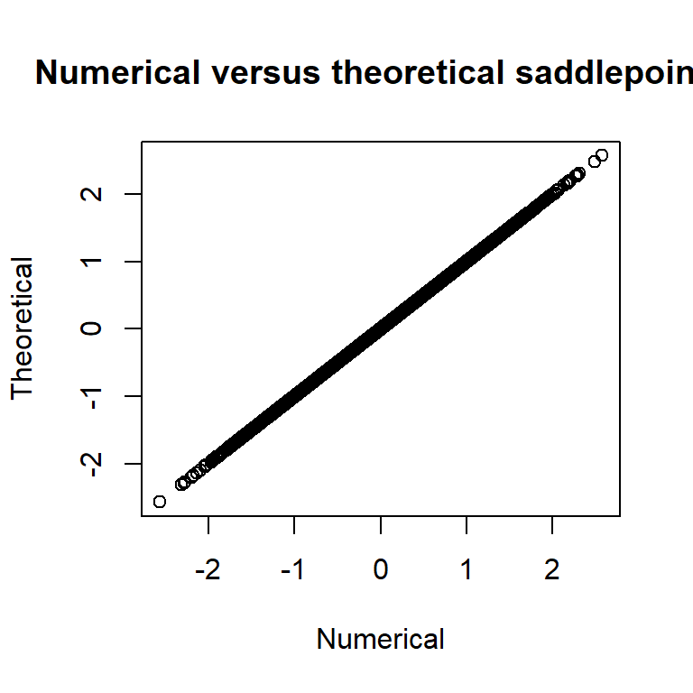

```r
# check s = normal sp and parameters
plot(summary(rep, "random")[,"Estimate"], (y-opt$par[1])/(exp(opt$par[2]))^2,
     main="Numerical versus theoretical saddlepoints",
     xlab="Numerical", ylab="Theoretical")
```

and we see that the numerical quantities matches the theoretical ones.

This is pretty cool! We now only need to supply the inner problem of the SPA (typically very little code) and a normalization constant, and **TMB** will take care of everything in the fastest possible way! I will proceed to make a pull request soon.

Butler, Ronald W. 2007. *Saddlepoint Approximations with Applications*. Cambridge University Press.

Kleppe, Tore Selland, and Hans J Skaug. 2008. “Building and Fitting Non-Gaussian Latent Variable Models via the Moment-Generating Function.” *Scandinavian Journal of Statistics* 35 (4). Wiley Online Library: 664–76.

Kristensen, Kasper, Anders Nielsen, Casper W Berg, Hans Skaug, and Bradley M Bell. 2016. “TMB: Automatic Differentiation and Laplace Approximation.” *Journal of Statistical Software* 70 (i05). Foundation for Open Access Statistics.

Searle, Shayle R, George Casella, and Charles E McCulloch. 2009. *Variance Components*. Vol. 391. John Wiley & Sons.

Skaug, Hans J, and David A Fournier. 2006. “Automatic Approximation of the Marginal Likelihood in Non-Gaussian Hierarchical Models.” *Computational Statistics & Data Analysis* 51 (2). Elsevier: 699–709.